# Dynamics of Happiness

Ankita Arvind Deshmukh

05/12/2022

## Introduction

What is happiness, exactly? How do we quantify it? Can you purchase happiness with money? Is pleasure determined by freedom or social support? Is it possible to define health as happiness? While these are contentious concerns, let us attempt to address them using a data-driven method utilizing the World Happiness Report 2021. The World Happiness Report is a remarkable assessment of global happiness. Happiness indices are increasingly being used by governments, businesses, and civil society to influence policy decisions and illustrate how well-being evaluations may be used to analyze a country’s progress.

## Data Source

Ajaypal Singh. “World Happiness Report 2021”. kaggle.com  
https://www.kaggle.com/ajaypalsinghlo/world-happiness-report-2021 (accessed Feb 17, 2022).

## Data Collection

The happiness scores and rankings use data from the Gallup World Poll which adopted the “Cantril’s Ladder of Life Scale” as an assessment for well-being. Since 2012, Gallup’s World Poll has published eight happiness reports. It asks of respondents:  
“Please imagine a ladder with steps numbered from zero at the bottom to 10 at the top. The top of the ladder represents the best possible life for you and the bottom of the ladder represents the worst possible life for you. On which step of the ladder would you say you personally feel you stand at this time? (ladder-present) On which step do you think you will stand about five years from now? (ladder-future)”

## Cases

The poll is conducted for 149 countries across the world. Each observation/row in a data set represents a country.

## Variables

There are total 20 variables in a dataset. But for the pourpose of this analysis, we can focus only on following variables:  
Ladder Score : Happiness Index (0 - 10)  
Logged GDP per capita  
Social support  
Healthy life expectancy  
Freedom to make life choices  
Generosity  
Perceptions of corruption  
The author has created columns for a hypothetical country Dystopia, that has values equal to the world’s lowest national averages for each of the six factors. They have no impact on the total score reported for each country. Hence those columns are not taken into consideration in this project.

## Type of study

It is an observational study (poll).

## Data clean-up

Let’s check for missing values and duplicated rows.

```r
world_happiness_report <- read.csv("world-happiness-report-2021.csv")
sum(is.na(world_happiness_report))
```

```
## [1] 0
```

```r
sum(duplicated(world_happiness_report))
```

```
## [1] 0
```

There are no missing values and no duplicated observations.  
Variable names (column names) contain white spaces, hence they can be renamed.

```r
names(world_happiness_report) <- c("country", "region", "ladder_score", "std_error_ladder_score", "upeerwhisker", "lowerwhisker", "gdp_per_cpt", "social_support", "healthy_life_exp", "freedom",  "generosity", "corruption", "ladder_score_dystopia", "expl_gdp_per_cpt", "expl_social_support", "expl_healthy_life_exp", "expl_freedom",  "expl_generosity", "expl_corruption","dystopia_residual")
```

```r
names(world_happiness_report)
```

```
##  [1] "country"                "region"                 "ladder_score"
##  [4] "std_error_ladder_score" "upeerwhisker"           "lowerwhisker"
##  [7] "gdp_per_cpt"            "social_support"         "healthy_life_exp"
## [10] "freedom"                "generosity"             "corruption"
## [13] "ladder_score_dystopia"  "expl_gdp_per_cpt"       "expl_social_support"
## [16] "expl_healthy_life_exp"  "expl_freedom"           "expl_generosity"
## [19] "expl_corruption"        "dystopia_residual"
```

Filter the variables required for this project.

```r
happiness_report <- world_happiness_report %>%
select(country, region, ladder_score, gdp_per_cpt, social_support, healthy_life_exp, freedom, generosity, corruption)
```

Data clean-up is done. Let’s work on this clean data now.

## Exploratory Data Analysis

Let’s visualize the correlation between various input variables and the happiness score (ladder score). ## Visualization

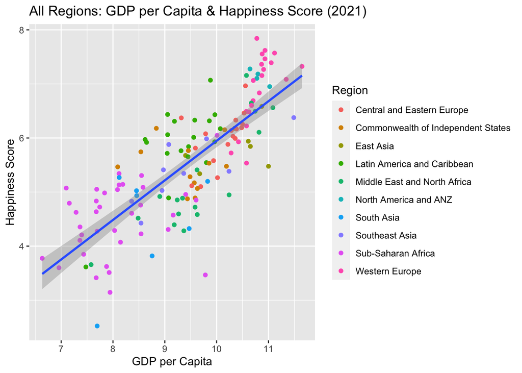

```r
ggplot(happiness_report, aes(x=gdp_per_cpt, y=ladder_score)) +
  geom_point(aes(color = region)) +
  geom_smooth(method="lm") +
  xlab("GDP per Capita") +
  ylab("Happiness Score") +
  labs(colour="Region") +
  ggtitle("All Regions: GDP per Capita & Happiness Score (2021)")
```

```r
cor(happiness_report$gdp_per_cpt,happiness_report$ladder_score)
```

```
## [1] 0.7897597
```

There is pretty high positive correlation between GDP per capita and the happiness score.

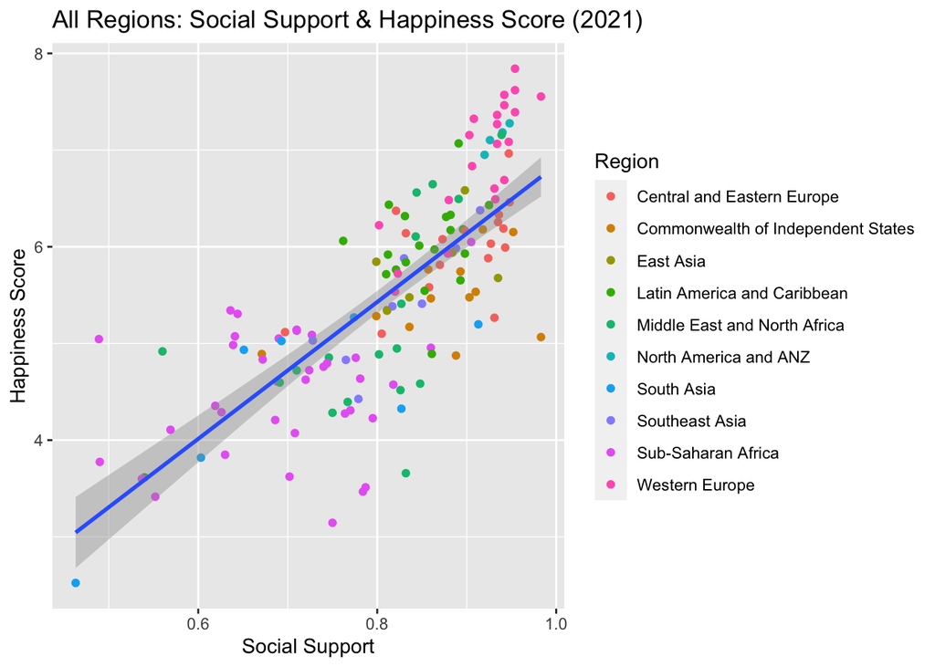

```r
ggplot(happiness_report, aes(x= social_support, y=ladder_score)) +
  geom_point(aes(color = region)) +
  geom_smooth(method="lm") +
  xlab("Social Support") +
  ylab("Happiness Score") +
  labs(colour="Region") +
  ggtitle("All Regions: Social Support & Happiness Score (2021)")
```

```r
cor(happiness_report$social_support,happiness_report$ladder_score)
```

```
## [1] 0.7568876
```

Social support does impact the happiness score positively.

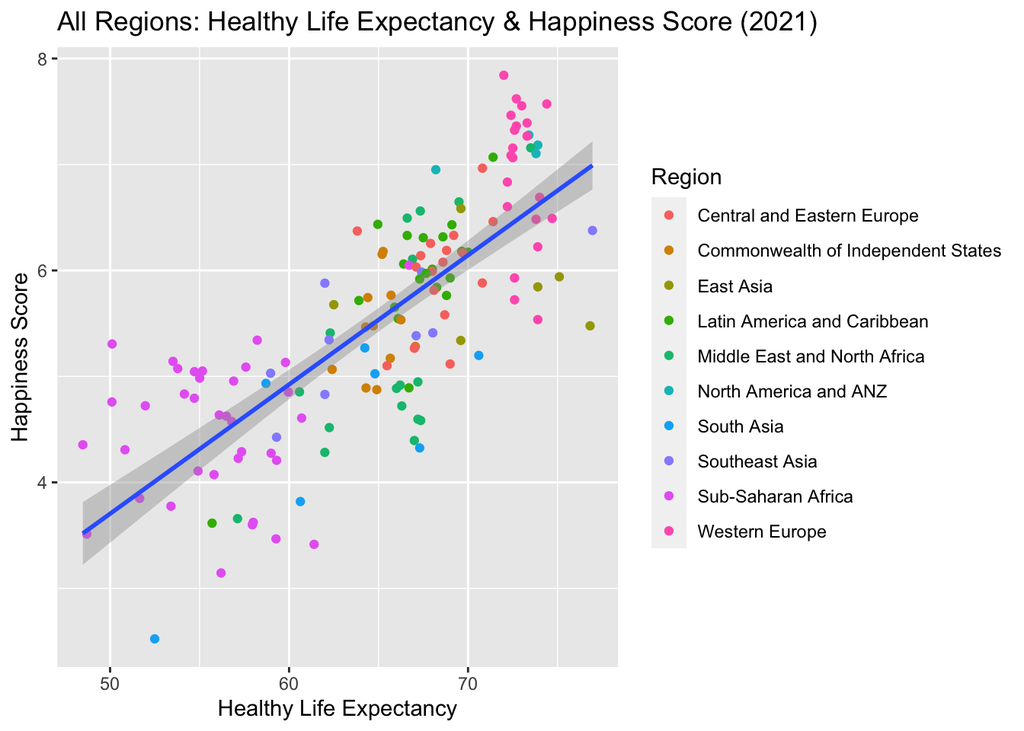

```r
ggplot(happiness_report, aes(x=healthy_life_exp, y=ladder_score)) +
  geom_point(aes(color = region)) +
  geom_smooth(method="lm") +
  xlab("Healthy Life Expectancy") +
  ylab("Happiness Score") +
  labs(colour="Region") +
  ggtitle("All Regions: Healthy Life Expectancy & Happiness Score (2021)")
```

```r
cor(happiness_report$healthy_life_exp,happiness_report$ladder_score)
```

```
## [1] 0.7680995
```

Happiness score seems to be improving with the health life expenctancy.

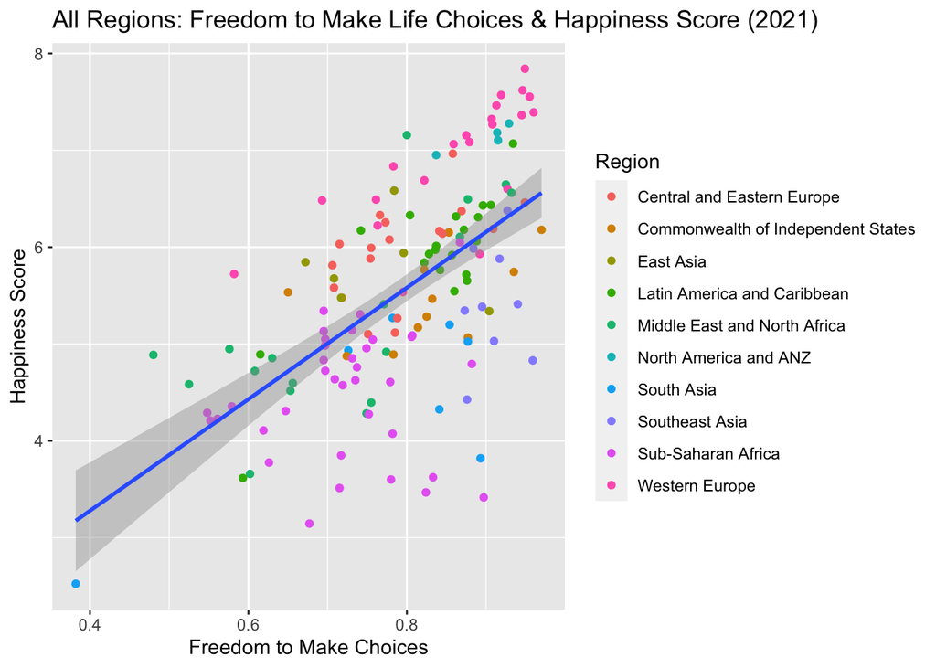

```r
ggplot(happiness_report, aes(x=freedom, y=ladder_score)) +
  geom_point(aes(color = region)) +
  geom_smooth(method="lm") +
  xlab("Freedom to Make Choices") +
  ylab("Happiness Score") +
  labs(colour="Region") +
  ggtitle("All Regions: Freedom to Make Life Choices & Happiness Score (2021)")
```

```r
cor(happiness_report$freedom,happiness_report$ladder_score)
```

```
## [1] 0.6077531
```

There is some positive correlation between freedom to make life choices & happiness score too.

```r
cor(happiness_report$generosity,happiness_report$ladder_score)
```

```
## [1] -0.01779928
```

```r
cor(happiness_report$corruption,happiness_report$ladder_score)
```

```
## [1] -0.42114
```

## Principal Component Analysis

```r
happiness_report_pca <- happiness_report %>%
select(gdp_per_cpt, social_support, healthy_life_exp, freedom, generosity, corruption)
head(happiness_report_pca,3)
```

```
##   gdp_per_cpt social_support healthy_life_exp freedom generosity corruption
## 1      10.775          0.954             72.0   0.949     -0.098      0.186
## 2      10.933          0.954             72.7   0.946      0.030      0.179
## 3      11.117          0.942             74.4   0.919      0.025      0.292
```

Let’s find the correlation matrix.

```r
#Find correlation matrix
cormat <- cor(happiness_report_pca)
cormat <- round(cormat, digits = 3)
cormat
```

```
##                  gdp_per_cpt social_support healthy_life_exp freedom generosity
## gdp_per_cpt            1.000          0.785            0.859   0.432     -0.199
## social_support         0.785          1.000            0.723   0.483     -0.115
## healthy_life_exp       0.859          0.723            1.000   0.461     -0.162
## freedom                0.432          0.483            0.461   1.000      0.169
## generosity            -0.199         -0.115           -0.162   0.169      1.000
## corruption            -0.342         -0.203           -0.364  -0.401     -0.164
##                  corruption
## gdp_per_cpt          -0.342
## social_support       -0.203
## healthy_life_exp     -0.364
## freedom              -0.401
## generosity           -0.164
## corruption            1.000
```

Find eigen values and eigen vectors.

```r
ev <- eigen(cormat)
#Finding eigen values
(values <- ev$values)
```

```
## [1] 3.1132783 1.2866242 0.7030608 0.5189581 0.2504582 0.1276203
```

```r
#Finding eigen vector
(vector <- ev$vectors)
```

```
##             [,1]       [,2]         [,3]        [,4]        [,5]        [,6]
## [1,] -0.51931086 -0.1797876  0.023619900  0.26033212 -0.15338221  0.77854725
## [2,] -0.48630909 -0.1480956  0.350074578  0.09120203  0.73900749 -0.25410443
## [3,] -0.51420764 -0.1289085 -0.004618408  0.23454124 -0.58573639 -0.56644069
## [4,] -0.37884038  0.3769137  0.195525361 -0.80678678 -0.14272887  0.07006724
## [5,]  0.06226332  0.7502536  0.471274144  0.45188930 -0.07585088  0.03444033
## [6,]  0.28637991 -0.4734788  0.785200022 -0.11743478 -0.24724446  0.04842012
```

Find percentage of variance explained.

```r
#Percent variance explained
PVE <- values / sum(values)
PVE
```

```
## [1] 0.51887972 0.21443737 0.11717680 0.08649302 0.04174303 0.02127006
```

```r
#Cumulative percent variance explained
cumsum(PVE)
```

```
## [1] 0.5188797 0.7333171 0.8504939 0.9369869 0.9787299 1.0000000
```

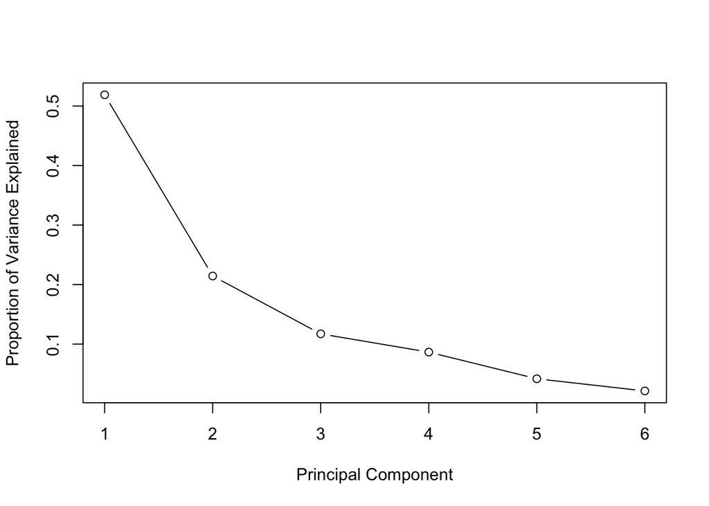

```r
plot(PVE, xlab = "Principal Component",
     ylab = "Proportion of Variance Explained",
     type = "b")
```

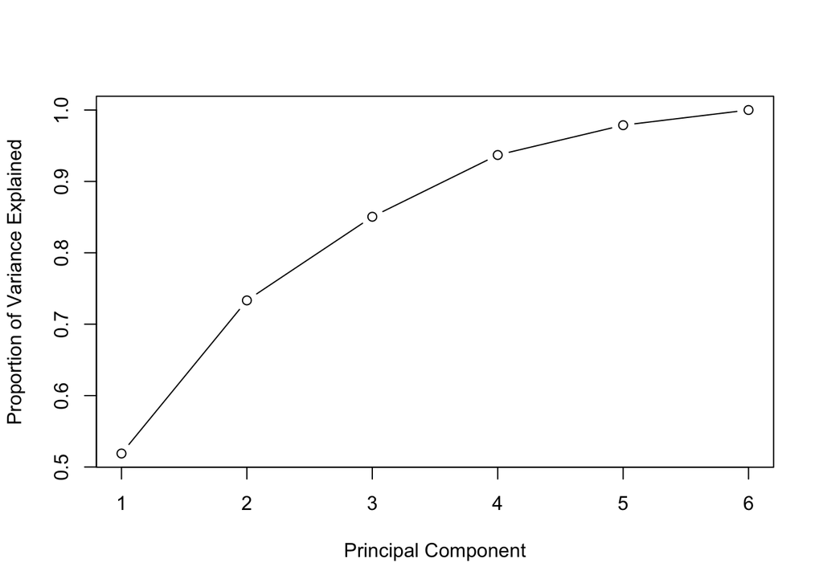

```r
plot(cumsum(PVE), xlab = "Principal Component",
     ylab = "Proportion of Variance Explained",
     type = "b")
```

From the calculations and charts above, it can be said that the first three components explain ~85% of the variability in the data. Hence dimensions of the matrix can be reduced at the cost of remaining ~15% variability.

```r
evecs = vector[,1:3]
colnames(evecs) = c("e1", "e2", "e3")
row.names(evecs) = colnames(happiness_report_pca)
evecs
```

```
##                           e1         e2           e3
## gdp_per_cpt      -0.51931086 -0.1797876  0.023619900
## social_support   -0.48630909 -0.1480956  0.350074578
## healthy_life_exp -0.51420764 -0.1289085 -0.004618408
## freedom          -0.37884038  0.3769137  0.195525361
## generosity        0.06226332  0.7502536  0.471274144
## corruption        0.28637991 -0.4734788  0.785200022
```

From the matrix above, GDP and healthy life expectancy seem to dominate the first principal component. Second principal components seems be dominated by generosity. Third component is highly dominated by corruption. Let’s find scaled principal components. We will use this later to perform multiple linear regression.

```r
PC1_t <- as.matrix(scale(happiness_report_pca)) %*% evecs[,1]
PC2_t <- as.matrix(scale(happiness_report_pca)) %*% evecs[,2]
PC3_t <- as.matrix(scale(happiness_report_pca)) %*% evecs[,3]
#PC4_t <- as.matrix(scale(happiness_report_pca)) %*% evecs1[,4]
PC_t  <- data.frame(PC1_t, PC2_t, PC3_t)
PC_t["Country"] <- happiness_report["country"]
head(PC_t,3)
```

```
##       PC1_t    PC2_t     PC3_t     Country
## 1 -3.149736 1.019762 -1.912868     Finland
## 2 -3.222043 1.627841 -1.545567     Denmark
## 3 -3.114248 1.169132 -1.146705 Switzerland
```

## Hypothesis testing:

## Hypothesis 1

Most of the countries in Western Europe, North America and ANZ (call it group North) are well-developed but there is a huge diversity in terms of income in Asian, African and Middle East countries (call it group South). Let’s check if variance of happiness index in group South is greater than that of group North.  
σ2n = Variance of happiness index in group North  
σ2s = Variance of happiness index in group South  
H0: σ2s = σ2n  
HA: σ2s > σ2n

## Test Statistic

Variance of happiness index between group North and group South.

## Reference Distribution

F-distribution can be used to make an inference on the Variances of two normal distribution because:  
1) Poll is taken from different individuals from different contries, hence the sample is independent.  
2) There is no clear outlier in the happiness index variable of either groups, the values are normally distributed.

```r
grpNorth <- subset(happiness_report, happiness_report$region == "Western Europe" | happiness_report$region == "North America and ANZ")
head(grpNorth,3)
```

```
##       country         region ladder_score gdp_per_cpt social_support
## 1     Finland Western Europe        7.842      10.775          0.954
## 2     Denmark Western Europe        7.620      10.933          0.954
## 3 Switzerland Western Europe        7.571      11.117          0.942
##   healthy_life_exp freedom generosity corruption
## 1             72.0   0.949     -0.098      0.186
## 2             72.7   0.946      0.030      0.179
## 3             74.4   0.919      0.025      0.292
```

```r
grpSouth <- subset(happiness_report, happiness_report$region == "South Asia" | happiness_report$region == "Sub-Saharan Africa" | happiness_report$region == "Middle East and North Africa")
head(grpSouth, 3)
```

```
##                 country                       region ladder_score gdp_per_cpt
## 12               Israel Middle East and North Africa        7.157      10.575
## 22              Bahrain Middle East and North Africa        6.647      10.669
## 25 United Arab Emirates Middle East and North Africa        6.561      11.085
##    social_support healthy_life_exp freedom generosity corruption
## 12          0.939           73.503   0.800      0.031      0.753
## 22          0.862           69.495   0.925      0.089      0.722
## 25          0.844           67.333   0.932      0.074      0.589
```

```r
var.test(grpNorth$ladder_score, grpSouth$ladder_score, alternative = "two.sided")
```

```
##
##  F test to compare two variances
##
## data:  grpNorth$ladder_score and grpSouth$ladder_score
## F = 0.49921, num df = 24, denom df = 59, p-value = 0.06284
## alternative hypothesis: true ratio of variances is not equal to 1
## 95 percent confidence interval:
##  0.2647113 1.0394510
## sample estimates:
## ratio of variances
##          0.4992146
```

The p-value of F-test is 0.06284 which is greater than the significance level 0.05. In conclusion, there is no significant difference between the two variances. Hence we fail to reject the NULL hypothesis H0: σ2a = σ2n.

## Hypothesis 2

Lets’ verify if mean happiness index in group North is greater than that of group south.  
μe: mean happiness index of group North  
μa: mean happiness index of group South  
H0: μn - μs = 0  
HA: μn - μs > 0

## Test Statistic

Difference in the sample means of happiness score between group North and group South in 2021.

## Reference Distribution

When small samples are taken, we assume that the populations are normally distributed and base our hypotheses tests on the t distribution. In this example, t-distribution can be used to make an inference because:  
1) Poll is taken from different individuals from different contries, hence the sample is independent.  
2) There is no clear outlier in the ‘happiness index’ variable of either groups, the values are normally distributed.

Since we failed to reject the null hypothesis in Hypothesis 1, we can perform pooled-t-test for hypothesis stated in Hypothesis 2.

```r
t.test(grpNorth$ladder_score, grpSouth$ladder_score, alternative = "greater", paired = FALSE, var.equal = TRUE, conf.level = 0.95)
```

```
##
##  Two Sample t-test
##
## data:  grpNorth$ladder_score and grpSouth$ladder_score
## t = 11.933, df = 83, p-value < 2.2e-16
## alternative hypothesis: true difference in means is greater than 0
## 95 percent confidence interval:
##  1.94087     Inf
## sample estimates:
## mean of x mean of y
##  6.949080  4.693833
```

Since p-value is less than 0.05, we reject null hypothesis. Hence we can say that group North has higher happiness index than that of group South in 2021.

## Multiple Regression

Since our model has more than one predictor variable and one response, we can use multiple regression model  
Y =β0 + β1𝑋1 + β2𝑋2 + βk𝑋k + 𝜖

```r
model <- lm(happiness_report$ladder_score~happiness_report$gdp_per_cpt+happiness_report$social_support+happiness_report$healthy_life_exp+happiness_report$freedom+happiness_report$generosity+happiness_report$corruption)
summary(model)
```

```
##
## Call:
## lm(formula = happiness_report$ladder_score ~ happiness_report$gdp_per_cpt +
##     happiness_report$social_support + happiness_report$healthy_life_exp +
##     happiness_report$freedom + happiness_report$generosity +
##     happiness_report$corruption)
##
## Residuals:
##      Min       1Q   Median       3Q      Max
## -1.85049 -0.30026  0.05735  0.33368  1.04878
##
## Coefficients:
##                                   Estimate Std. Error t value Pr(>|t|)
## (Intercept)                       -2.23722    0.63049  -3.548 0.000526 ***
## happiness_report$gdp_per_cpt       0.27953    0.08684   3.219 0.001595 **
## happiness_report$social_support    2.47621    0.66822   3.706 0.000301 ***
## happiness_report$healthy_life_exp  0.03031    0.01333   2.274 0.024494 *
## happiness_report$freedom           2.01046    0.49480   4.063 7.98e-05 ***
## happiness_report$generosity        0.36438    0.32121   1.134 0.258541
## happiness_report$corruption       -0.60509    0.29051  -2.083 0.039058 *
## ---
## Signif. codes:  0 '***' 0.001 '**' 0.01 '*' 0.05 '.' 0.1 ' ' 1
##
## Residual standard error: 0.5417 on 142 degrees of freedom
## Multiple R-squared:  0.7558, Adjusted R-squared:  0.7455
## F-statistic: 73.27 on 6 and 142 DF,  p-value: < 2.2e-16
```

F-statistic is a good indicator of whether there is a relationship between our predictor and the response variables. The further the F-statistic is from 1 the better it is. In our example the F-statistic is 73.27 which is relatively larger than 1 given the size of our data.

It can also be seen that p-value is < 2.2e-16, which is highly significant. This means that, at least, one of the predictor variables is significantly related to the outcome variable. From the coefficients table, it seems that Social support and freedom are the most significant attributes.

‘R-squared’ is an important measures of how well our model predicts the desired response variable which is equal to 0.7558 in our case. This value means that combination of GDP per capita, social support, healthy life expectancy, freedom of expression, generosity and corruption explain 75.58% of the variability in ‘happiness score’.

Let’s also see if fitting a model based on PCA makes a difference since the dimension are reduced.

```r
pca_model <- lm(happiness_report$ladder_score~PC1_t+PC2_t+PC3_t)
summary(pca_model)
```

```
##
## Call:
## lm(formula = happiness_report$ladder_score ~ PC1_t + PC2_t +
##     PC3_t)
##
## Residuals:
##      Min       1Q   Median       3Q      Max
## -1.79830 -0.31707  0.08048  0.34345  1.11549
##
## Coefficients:
##             Estimate Std. Error t value Pr(>|t|)
## (Intercept)  5.53284    0.04400 125.742   <2e-16 ***
## PC1_t       -0.52590    0.02502 -21.021   <2e-16 ***
## PC2_t        0.05161    0.03892   1.326   0.1869
## PC3_t        0.09154    0.05266   1.738   0.0843 .
## ---
## Signif. codes:  0 '***' 0.001 '**' 0.01 '*' 0.05 '.' 0.1 ' ' 1
##
## Residual standard error: 0.5371 on 145 degrees of freedom
## Multiple R-squared:  0.7549, Adjusted R-squared:  0.7499
## F-statistic: 148.9 on 3 and 145 DF,  p-value: < 2.2e-16
```

```r
confint(pca_model)
```

```
##                   2.5 %     97.5 %
## (Intercept)  5.44587186  5.6198060
## PC1_t       -0.57534488 -0.4764535
## PC2_t       -0.02531541  0.1285312
## PC3_t       -0.01253299  0.1956223
```

The R-squared value remains almost same but the value of F-statistic has notably increased.

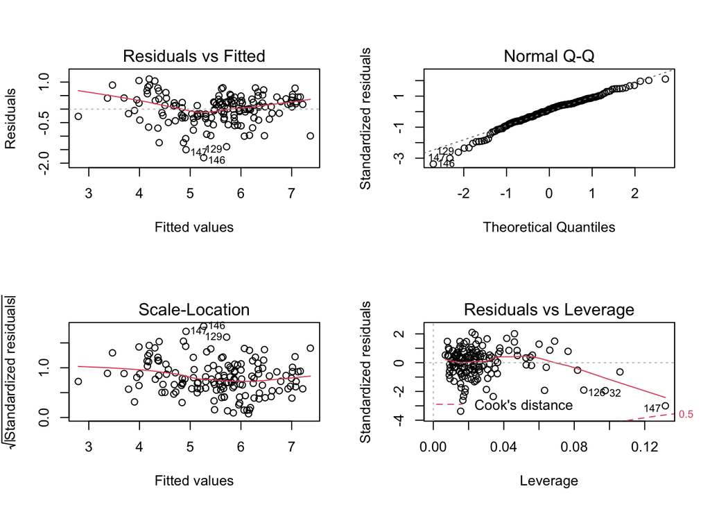

```r
par(mfrow = c(2,2))
plot(pca_model)
```

Graph 1 is called as fitted vs residual plot. The red line is quite flat, in fact, the points are compact and look like a cloud of points. Hence linearity assumptions is met.  
Graph 2 is known as QQ plot. The Y-axis is ordered, observed and standardized residuals. X-axis has ordered theoretical residuals. The points should fall roughly on the diagonal line and they do. Hence the assumption about the normal distribution of errors is also met.  
Graph 3 and 4 also indicate linearity and almost constant variance.

## Conclusion:

Multiple linear regression suggests that family support and freedom of expression are the most important factors to consider when determining happiness. Despite the numerous disagreements, it appears that happiness is also strongly linked to wealth. Nations with high happiness scores are also economically prosperous. Even though it is not mentioned in this survey, demography should, in my opinion, play a role in determining happiness. In the future, it would be fascinating to investigate the impact of this characteristics on happiness, as well as track how the data changes over time.

## References:

-Changing World Happiness https://worldhappiness.report/ed/2019/changing-world-happiness/  
-Visualization & EDA on World Happiness Report by Merve ozgul https://rstudio-pubs-static.s3.amazonaws.com/464157_8443c5d697da405b91f41ada1e217064.html